# Penguin Assignment

2022-12-06

## Load all necessary packages

```r
library(palmerpenguins)
library(ggplot2)
library(tidyverse)
library(janitor)
library(dplyr)
library(svglite)
library(ragg)
library(car)
```

## Visualising our data frame

##### Can see that the column headers are messy and not uniform, they need to be cleaned up.

```r
head(penguins_raw)
```

```
## # A tibble: 6 × 17
##   studyName `Sample Number` Species          Region Island Stage `Individual ID`
##   <chr>               <dbl> <chr>            <chr>  <chr>  <chr> <chr>
## 1 PAL0708                 1 Adelie Penguin … Anvers Torge… Adul… N1A1
## 2 PAL0708                 2 Adelie Penguin … Anvers Torge… Adul… N1A2
## 3 PAL0708                 3 Adelie Penguin … Anvers Torge… Adul… N2A1
## 4 PAL0708                 4 Adelie Penguin … Anvers Torge… Adul… N2A2
## 5 PAL0708                 5 Adelie Penguin … Anvers Torge… Adul… N3A1
## 6 PAL0708                 6 Adelie Penguin … Anvers Torge… Adul… N3A2
## # … with 10 more variables: `Clutch Completion` <chr>, `Date Egg` <date>,
## #   `Culmen Length (mm)` <dbl>, `Culmen Depth (mm)` <dbl>,
## #   `Flipper Length (mm)` <dbl>, `Body Mass (g)` <dbl>, Sex <chr>,
## #   `Delta 15 N (o/oo)` <dbl>, `Delta 13 C (o/oo)` <dbl>, Comments <chr>
```

##### To save a version of our original dataframe

```r
write.csv(penguins_raw, "data_raw/penguins_raw.csv")
```

##### Creating a cleaning function

```r
cleaning <- function(data_raw){
  data_raw %>%
    select(-starts_with("Delta")) %>%
    select(-Comments) %>%
    clean_names() %>%
    remove_empty(c("rows","cols"))
}
```

##### Applying our cleaning function to the raw penguin data, creating a new dataframe called penguins_clean.

```r
penguins_clean <- cleaning(penguins_raw)

write.csv(penguins_clean, "data_clean/penguins_clean")

penguins_clean
```

```
## # A tibble: 344 × 14
##    study_name sample_number species            region island stage individual_id
##    <chr>              <dbl> <chr>              <chr>  <chr>  <chr> <chr>
##  1 PAL0708                1 Adelie Penguin (P… Anvers Torge… Adul… N1A1
##  2 PAL0708                2 Adelie Penguin (P… Anvers Torge… Adul… N1A2
##  3 PAL0708                3 Adelie Penguin (P… Anvers Torge… Adul… N2A1
##  4 PAL0708                4 Adelie Penguin (P… Anvers Torge… Adul… N2A2
##  5 PAL0708                5 Adelie Penguin (P… Anvers Torge… Adul… N3A1
##  6 PAL0708                6 Adelie Penguin (P… Anvers Torge… Adul… N3A2
##  7 PAL0708                7 Adelie Penguin (P… Anvers Torge… Adul… N4A1
##  8 PAL0708                8 Adelie Penguin (P… Anvers Torge… Adul… N4A2
##  9 PAL0708                9 Adelie Penguin (P… Anvers Torge… Adul… N5A1
## 10 PAL0708               10 Adelie Penguin (P… Anvers Torge… Adul… N5A2
## # … with 334 more rows, and 7 more variables: clutch_completion <chr>,
## #   date_egg <date>, culmen_length_mm <dbl>, culmen_depth_mm <dbl>,
## #   flipper_length_mm <dbl>, body_mass_g <dbl>, sex <chr>
```

## Running a statistical test

###### First I chose what question I wanted to ask. Is there a difference between male and female body mass in Adelie penguins?

###### H0: The difference between male and female Adelie Penguin body mass mean is 0 . µ1 = µ2

###### H1: The difference between male and female Adelie Penguin body mass mean is not 0. µ1 ≠ µ2

###### As I am comparing the means of two independent groups to each other I will run a two-sample t-test. To do this I need to remove data from my dataframe that I am not interested in; i.e. non-Adelie penguins.

```r
adelie0 <- penguins_clean[-c(153:344), ]
adelie <- na.omit(adelie0)
adelie
```

```
## # A tibble: 146 × 14
##    study_name sample_number species            region island stage individual_id
##    <chr>              <dbl> <chr>              <chr>  <chr>  <chr> <chr>
##  1 PAL0708                1 Adelie Penguin (P… Anvers Torge… Adul… N1A1
##  2 PAL0708                2 Adelie Penguin (P… Anvers Torge… Adul… N1A2
##  3 PAL0708                3 Adelie Penguin (P… Anvers Torge… Adul… N2A1
##  4 PAL0708                5 Adelie Penguin (P… Anvers Torge… Adul… N3A1
##  5 PAL0708                6 Adelie Penguin (P… Anvers Torge… Adul… N3A2
##  6 PAL0708                7 Adelie Penguin (P… Anvers Torge… Adul… N4A1
##  7 PAL0708                8 Adelie Penguin (P… Anvers Torge… Adul… N4A2
##  8 PAL0708               13 Adelie Penguin (P… Anvers Torge… Adul… N7A1
##  9 PAL0708               14 Adelie Penguin (P… Anvers Torge… Adul… N7A2
## 10 PAL0708               15 Adelie Penguin (P… Anvers Torge… Adul… N8A1
## # … with 136 more rows, and 7 more variables: clutch_completion <chr>,
## #   date_egg <date>, culmen_length_mm <dbl>, culmen_depth_mm <dbl>,
## #   flipper_length_mm <dbl>, body_mass_g <dbl>, sex <chr>
```

###### Before I can run the t-test I need to test its assumptions. First I test that both populations’ (male and female) body mass are normally distributed and then test whether they have similar variance.

##### Creating a dataframe with only female Adelie penguins.

```r
adelieF <- adelie %>% filter(sex == 'FEMALE')
adelieF
```

```
## # A tibble: 73 × 14
##    study_name sample_number species            region island stage individual_id
##    <chr>              <dbl> <chr>              <chr>  <chr>  <chr> <chr>
##  1 PAL0708                2 Adelie Penguin (P… Anvers Torge… Adul… N1A2
##  2 PAL0708                3 Adelie Penguin (P… Anvers Torge… Adul… N2A1
##  3 PAL0708                5 Adelie Penguin (P… Anvers Torge… Adul… N3A1
##  4 PAL0708                7 Adelie Penguin (P… Anvers Torge… Adul… N4A1
##  5 PAL0708               13 Adelie Penguin (P… Anvers Torge… Adul… N7A1
##  6 PAL0708               16 Adelie Penguin (P… Anvers Torge… Adul… N8A2
##  7 PAL0708               17 Adelie Penguin (P… Anvers Torge… Adul… N9A1
##  8 PAL0708               19 Adelie Penguin (P… Anvers Torge… Adul… N10A1
##  9 PAL0708               21 Adelie Penguin (P… Anvers Biscoe Adul… N11A1
## 10 PAL0708               23 Adelie Penguin (P… Anvers Biscoe Adul… N12A1
## # … with 63 more rows, and 7 more variables: clutch_completion <chr>,
## #   date_egg <date>, culmen_length_mm <dbl>, culmen_depth_mm <dbl>,
## #   flipper_length_mm <dbl>, body_mass_g <dbl>, sex <chr>
```

##### Creating a dataframe with only male Adelie penguins.

```r
adelieM <- adelie %>% filter(sex == 'MALE')
adelieM
```

```
## # A tibble: 73 × 14
##    study_name sample_number species            region island stage individual_id
##    <chr>              <dbl> <chr>              <chr>  <chr>  <chr> <chr>
##  1 PAL0708                1 Adelie Penguin (P… Anvers Torge… Adul… N1A1
##  2 PAL0708                6 Adelie Penguin (P… Anvers Torge… Adul… N3A2
##  3 PAL0708                8 Adelie Penguin (P… Anvers Torge… Adul… N4A2
##  4 PAL0708               14 Adelie Penguin (P… Anvers Torge… Adul… N7A2
##  5 PAL0708               15 Adelie Penguin (P… Anvers Torge… Adul… N8A1
##  6 PAL0708               18 Adelie Penguin (P… Anvers Torge… Adul… N9A2
##  7 PAL0708               20 Adelie Penguin (P… Anvers Torge… Adul… N10A2
##  8 PAL0708               22 Adelie Penguin (P… Anvers Biscoe Adul… N11A2
##  9 PAL0708               24 Adelie Penguin (P… Anvers Biscoe Adul… N12A2
## 10 PAL0708               25 Adelie Penguin (P… Anvers Biscoe Adul… N13A1
## # … with 63 more rows, and 7 more variables: clutch_completion <chr>,
## #   date_egg <date>, culmen_length_mm <dbl>, culmen_depth_mm <dbl>,
## #   flipper_length_mm <dbl>, body_mass_g <dbl>, sex <chr>
```

##### Testing normality in females using a qqplot.

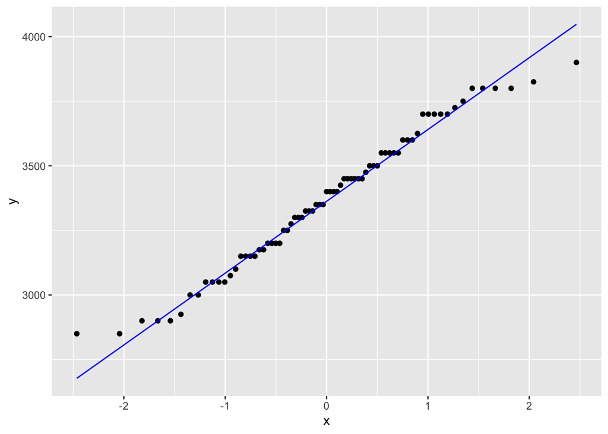

```r
ggplot(adelieF, aes(sample = body_mass_g)) +
  geom_qq() +
  geom_qq_line(colour = "blue")
```

##### Testing normality in males using a qqplot

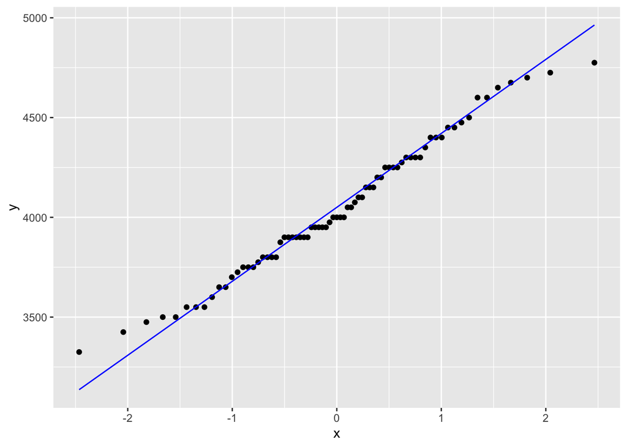

```r
ggplot(adelieM, aes(sample = body_mass_g)) +
  geom_qq() +
  geom_qq_line(colour = "blue")
```

###### I would conclude that both data are normally distrubuted; at the tail ends there are some slight deviations however t-tests are robust to some deviation from normality.

##### To check that the variance between the populations are equal I use a Levene test To do this the ‘car’ package is required. H0: The two varainces are equal. H1: The two variances are not equal.

```r
leveneTest(data = adelie, body_mass_g ~ sex, centre = mean)
```

```
## Levene's Test for Homogeneity of Variance (center = median: mean)
##        Df F value  Pr(>F)
## group   1  3.8664 0.05118 .
##       144
## ---
## Signif. codes:  0 '***' 0.001 '**' 0.01 '*' 0.05 '.' 0.1 ' ' 1
```

###### As the p-value is greater than 0.05 the two variances are not significantly different from each other and so we do not reject the null.

##### Now that my assumptions have been tested and met I can carry out my two-sample t-test.

```r
t.test(data = adelie, body_mass_g ~ sex, var.equal = TRUE)
```

```
##
##  Two Sample t-test
##
## data:  body_mass_g by sex
## t = -13.126, df = 144, p-value < 2.2e-16
## alternative hypothesis: true difference in means between group FEMALE and group MALE is not equal to 0
## 95 percent confidence interval:
##  -776.2484 -573.0666
## sample estimates:
## mean in group FEMALE   mean in group MALE
##             3368.836             4043.493
```

###### The p-value produced is significantly lower than 0.05 meaning we can be confident that there is a difference between the two means. Therefore we reject the null hypothesis and conclude there is likely a difference between mean male and mean female body weight in Adelie penguins.

## Creating the figure

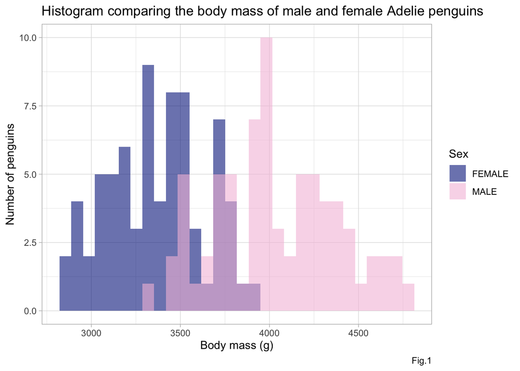

```r
body_mass_hist <- ggplot(data = adelie, aes(x = body_mass_g, fill = sex)) +
  geom_histogram(position = "Identity", bins = 30, alpha = 0.6) + #position = "Identity" is what produces the overlapping histograms
  scale_fill_manual(values = c("#06238b", "#f4c1dc")) + #choosing the colours for sex
  labs(x = "Body mass (g)",
       y = "Number of penguins", fill = "Sex",
       title = "Histogram comparing the body mass of male and female Adelie penguins",
       caption = "Fig.1") +
  theme_light()

body_mass_hist
```

###### I decided to produce two overlapping histograms so that you can clearly see where the two peaks are as well as seeing overlap between the two populations. From the graph can see that female body mass peaks around 3300g while male peaks around 4000g. These two visually distinct peaks give us greater confidence that our t-test is correct. Furthermore, I have chosen two colours from the opposite ends of the batlow scale in order for the two different populations to be visible to people across the colourblind spectrumn.

## Saving the figure

##### As a png.

```r
body_mass_hist
```

```r
agg_png("Penguin Project/figures/highres.png",
       width = 800, height = 600, units = "px",
        res=300,
       scaling = 0.4
        )
body_mass_hist
```

###### To save the image to your directory you need to change the bit between “” to your chosen filepath.

##### As a vector.

```r
body_mass_hist
```

```r
svglite("Penguin Project/figures/8*6.svg",
        width = 8, height = 6)
body_mass_hist
```